# IE 360 HW4-5

Atakan Demirkan

3 Temmuz 2021

# Introduction

### Description

Everyday, millions of people purchase many different items via online shopping websites. As Internet evolves throughout years, online shopping became one of the most important sectors around world. Trendyol.com is the largest mobile commerce company in Turkey and the MENA region selling more than 70 million items per year. Considering the wide product spectrum and strong sales of Trendyol, the correct decisions should be made with great precision in order to continue the operation successfully. Deciding how many products to sell in the future is one of the most important of these decisions. Forecasting the sales quantity of a product for an online retail is a challenging task. The aim of this assignment is to build a forecasting model for the sales quantities of 9 different products.

### Required Libraries

Firstly, I initiated required libraries.

```r
library(jsonlite)
library(httr)
library(data.table)
library(stats)
library(forecast)
library(ggplot2)
library(tidyverse)
library(lubridate)
library(GGally)
library(corrplot)
library(dplyr)
library(tidyr)
library(readxl)
library(zoo)
library(corrplot)
library(hrbrthemes)
library(viridis)
```

### Reading Data

```r
get_token <- function(username, password, url_site){

  post_body = list(username=username,password=password)
  post_url_string = paste0(url_site,'/token/')
  result = POST(post_url_string, body = post_body)

  # error handling (wrong credentials)
  if(result$status_code==400){
    print('Check your credentials')
    return(0)
  }
  else if (result$status_code==201){
    output = content(result)
    token = output$key
  }

  return(token)
}

get_data <- function(start_date='2020-03-20', token, url_site){

  post_body = list(start_date=start_date,username=username,password=password)
  post_url_string = paste0(url_site,'/dataset/')

  header = add_headers(c(Authorization=paste('Token',token,sep=' ')))
  result = GET(post_url_string, header, body = post_body)
  output = content(result)
  data = data.table::rbindlist(output)
  data[,event_date:=as.Date(event_date)]
  data = data[order(product_content_id,event_date)]
  return(data)
}


send_submission <- function(predictions, token, url_site, submit_now=F){

  format_check=check_format(predictions)
  if(!format_check){
    return(FALSE)
  }

  post_string="list("
  for(i in 1:nrow(predictions)){
    post_string=sprintf("%s'%s'=%s",post_string,predictions$product_content_id[i],predictions$forecast[i])
    if(i<nrow(predictions)){
      post_string=sprintf("%s,",post_string)
    } else {
      post_string=sprintf("%s)",post_string)
    }
  }

  submission = eval(parse(text=post_string))
  json_body = jsonlite::toJSON(submission, auto_unbox = TRUE)
  submission=list(submission=json_body)

  print(submission)
  # {"31515569":2.4,"32737302":2.4,"32939029":2.4,"4066298":2.4,"48740784":2.4,"6676673":2.4, "7061886":2.4, "73318567":2.4, "85004":2.4}

  if(!submit_now){
    print("You did not submit.")
    return(FALSE)
  }


  header = add_headers(c(Authorization=paste('Token',token,sep=' ')))
  post_url_string = paste0(url_site,'/submission/')
  result = POST(post_url_string, header, body=submission)

  if (result$status_code==201){
    print("Successfully submitted. Below you can see the details of your submission")
  } else {
    print("Could not submit. Please check the error message below, contact the assistant if needed.")
  }

  print(content(result))

}

check_format <- function(predictions){

  if(is.data.frame(predictions) | is.data.frame(predictions)){
    if(all(c('product_content_id','forecast') %in% names(predictions))){
      if(is.numeric(predictions$forecast)){
        print("Format OK")
        return(TRUE)
      } else {
        print("forecast information is not numeric")
        return(FALSE)
      }
    } else {
      print("Wrong column names. Please provide 'product_content_id' and 'forecast' columns")
      return(FALSE)
    }

  } else {
    print("Wrong format. Please provide data.frame or data.table object")
    return(FALSE)
  }

}

# this part is main code
subm_url = 'http://46.101.163.177'

u_name = "Group11"
p_word = "UcZ2v9SNRuqpQL62"
submit_now = FALSE

username = u_name
password = p_word

token = get_token(username=u_name, password=p_word, url=subm_url)
data = get_data(token=token,url=subm_url)
data
```

```
##      price event_date product_content_id sold_count visit_count favored_count
##   1: 60.44 2021-05-02           31515569        523       24463          1778
##   2: 59.99 2021-05-03           31515569        533       20562          1462
##   3: 60.25 2021-05-04           31515569        451       19091          1321
##   4: 59.99 2021-05-05           31515569        498       19407          1236
##   5: 60.30 2021-05-06           31515569        573       20543          1344
##  ---
## 554: 80.49 2021-06-28              85004         80        2852           326
## 555: 79.90 2021-06-29              85004        121        3136           359
## 556: 81.56 2021-06-30              85004         87        3063           401
## 557: 88.27 2021-07-01              85004         54        2801           415
## 558: 90.67 2021-07-02              85004         36        2156           290
##      basket_count category_sold category_brand_sold category_visits ty_visits
##   1:         2636          1880              103788           17565 169038376
##   2:         2240          2030               88629           17592 168766437
```

[output cut: 21 more lines]

```r
date_to_forecast="2021-06-26"
```

```r
my_data= read.csv("C:\\Users\\aadem\\OneDrive\\Desktop\\ProjectRawData.csv")
my_data=as.data.table(my_data)
my_data$event_date=ymd(my_data$event_date)
str(my_data)
```

```
## Classes 'data.table' and 'data.frame':   4331 obs. of  13 variables:
##  $ event_date         : Date, format: "2021-05-31" "2021-05-31" ...
##  $ product_content_id : int  85004 4066298 6676673 7061886 31515569 32737302 32939029 48740784 73318567 85004 ...
##  $ price              : num  87.4 65.8 120.7 294.4 60.3 ...
##  $ sold_count         : int  80 1398 345 24 454 44 125 2 175 85 ...
##  $ visit_count        : int  6002 19102 19578 1485 20114 5017 5301 221 20256 5265 ...
##  $ basket_count       : int  744 5096 1261 81 2871 316 608 15 965 633 ...
##  $ favored_count      : int  1642 1703 1510 122 2102 607 698 22 1960 1104 ...
##  $ category_sold      : int  5048 6547 4944 951 8155 5198 930 1684 5198 4117 ...
##  $ category_visits    : int  236197 108811 306462 95645 637143 1010634 41973 329087 1010634 215260 ...
##  $ category_basket    : int  33681 28558 23418 4704 49389 33728 3911 12614 33728 25181 ...
##  $ category_favored   : int  40472 11913 26597 8886 62460 96699 5791 24534 96699 36225 ...
##  $ category_brand_sold: int  743 4286 786 179 1759 3665 875 12 3665 430 ...
##  $ ty_visits          : int  125439876 125439876 125439876 125439876 125439876 125439876 125439876 125439876 125439876 131821083 ...
##  - attr(*, ".internal.selfref")=<externalptr>
```

```r
summary(my_data)
```

```
##    event_date         product_content_id     price          sold_count
##  Min.   :2020-05-25   Min.   :   85004   Min.   : 38.99   Min.   :    0.0
##  1st Qu.:2020-08-25   1st Qu.: 6676673   1st Qu.: 64.28   1st Qu.:    1.0
##  Median :2020-11-26   Median :31515569   Median : 80.87   Median :   46.0
##  Mean   :2020-11-26   Mean   :26349012   Mean   :129.76   Mean   :  207.7
##  3rd Qu.:2021-02-27   3rd Qu.:32939029   3rd Qu.:141.86   3rd Qu.:  240.0
##  Max.   :2021-05-31   Max.   :73318567   Max.   :833.32   Max.   :10879.0
##  NA's   :983          NA's   :983        NA's   :1798     NA's   :983
##   visit_count      basket_count     favored_count     category_sold
##  Min.   :     0   Min.   :    0.0   Min.   :    0.0   Min.   :    0.0
##  1st Qu.:     0   1st Qu.:    7.0   1st Qu.:    0.0   1st Qu.:  153.0
##  Median :     0   Median :  208.0   Median :    0.0   Median :  562.0
##  Mean   :  2893   Mean   :  857.5   Mean   :  359.2   Mean   :  890.5
##  3rd Qu.:  1480   3rd Qu.:  942.0   3rd Qu.:  350.2   3rd Qu.: 1124.0
##  Max.   :132126   Max.   :26491.0   Max.   :12063.0   Max.   :15916.0
##  NA's   :983      NA's   :983       NA's   :983       NA's   :983
##  category_visits   category_basket   category_favored category_brand_sold
##  Min.   :    107   Min.   :      0   Min.   :   628   Min.   :     0
##  1st Qu.:    835   1st Qu.:      0   1st Qu.:  3741   1st Qu.:     0
##  Median :   2448   Median :      0   Median : 11188   Median :     0
##  Mean   :   7330   Mean   : 129733   Mean   : 18255   Mean   : 17133
##  3rd Qu.:   5105   3rd Qu.:  74697   3rd Qu.: 24907   3rd Qu.: 21051
##  Max.   :1335060   Max.   :3102147   Max.   :244883   Max.   :259590
##  NA's   :983       NA's   :983       NA's   :983      NA's   :983
##    ty_visits
##  Min.   :        1
##  1st Qu.:        1
##  Median :        1
##  Mean   : 39145174
##  3rd Qu.: 97619487
##  Max.   :178545693
##  NA's   :983
```

# Task 1 & Task 2

## Product 1

### Data Adjustments

I added new data and sorted observations from old to new.

```r
product1= my_data[my_data$product_content_id==31515569,]
product1=(product1[order(product1$event_date),])
prd1_add=data[data$product_content_id==31515569,]
prd1_add=prd1_add[event_date>="2021-06-01",]
prd1_add
```

```
##     price event_date product_content_id sold_count visit_count favored_count
##  1: 60.09 2021-06-01           31515569        817       31915          4044
##  2: 60.10 2021-06-02           31515569        746       23940          3161
##  3: 60.39 2021-06-03           31515569        721       17792          1930
##  4: 60.34 2021-06-04           31515569        466       11924           846
##  5: 59.99 2021-06-05           31515569        153        8776           614
##  6: 60.17 2021-06-06           31515569        226        8198           587
##  7: 60.29 2021-06-07           31515569        138        6524           468
##  8: 60.22 2021-06-08           31515569        175        6743           504
##  9: 51.51 2021-06-09           31515569        530       15889           975
## 10: 50.99 2021-06-10           31515569        528       13988           870
## 11: 57.59 2021-06-11           31515569        199        8015           598
## 12: 59.99 2021-06-12           31515569        144        6266           486
## 13: 60.20 2021-06-13           31515569        179        6974           464
## 14: 59.99 2021-06-14           31515569        218        8118           487
```

[output cut: 87 more lines]

```r
product1=rbind(product1,prd1_add)
```

### Visualizing

The plot of the series is shown below. When the data is visually analyzed, it is difficult to talk about any seasonality. In some periods, deviations from the normal levels were observed. Any promotion may have been made on these dates.

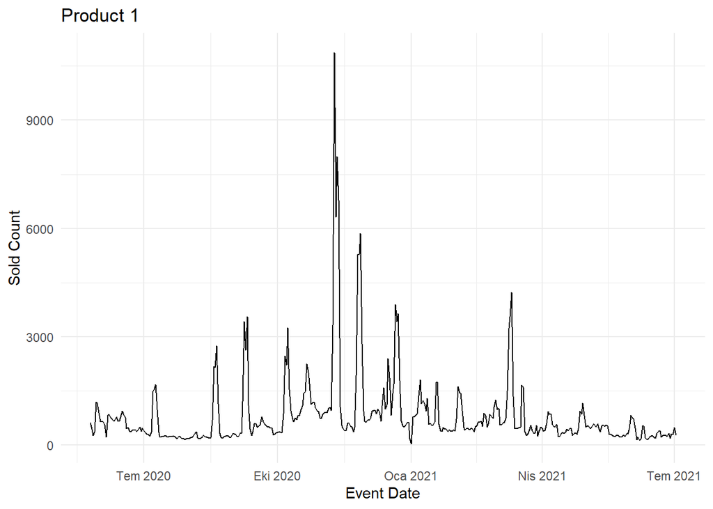

```r
(ggplot(product1,aes(x=event_date,y=sold_count))+
  geom_line()+
  theme_minimal()+
  labs(title="Product 1",y="Sold Count", x="Event Date"))
```

### Analyze Seasonality

In addition to visual analysis, I also used the acf function to test seasonality. Autocorrelation values above the critical value were observed in some lag values.

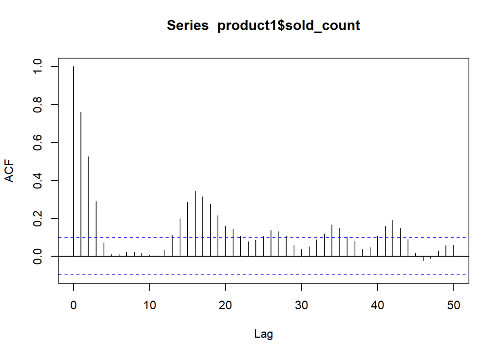

```r
acf(product1$sold_count,50)
```

### Decomposition

I made multiplicative and additive decomposition in weekly and monthly level.

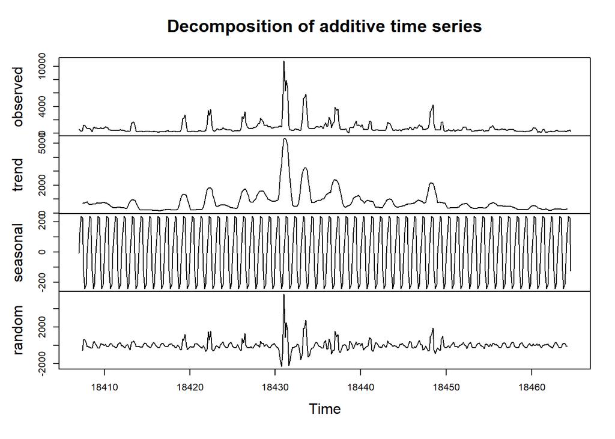

```r
pr1_ts_w=ts(product1$sold_count, frequency=7,start = min(product1$event_date))
pr1_ts_decompose_wa=decompose(pr1_ts_w)
pr1_ts_decompose_wm=decompose(pr1_ts_w, type="multiplicative")
plot(pr1_ts_decompose_wa)
```

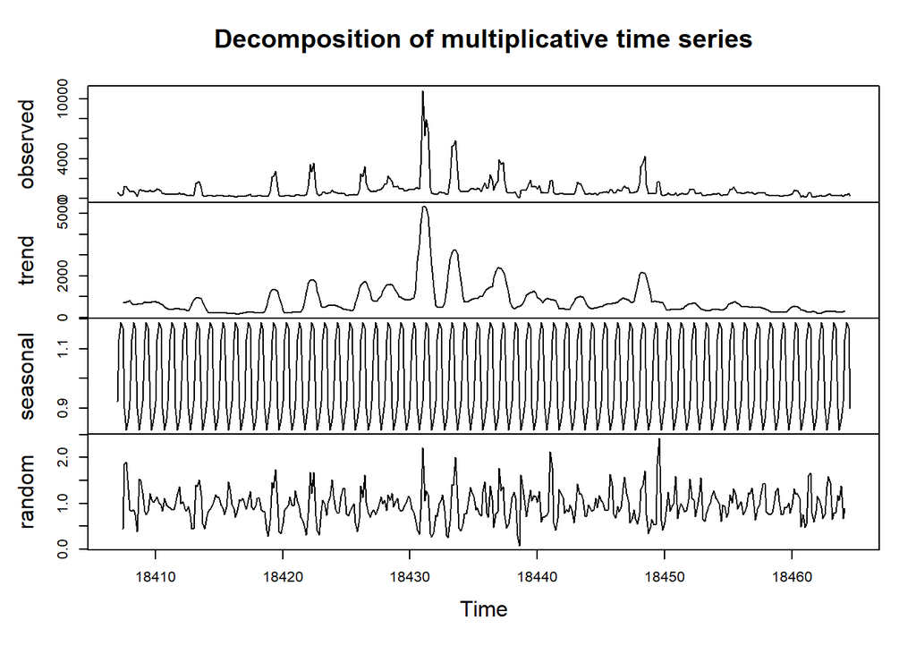

```r
plot(pr1_ts_decompose_wm)
```

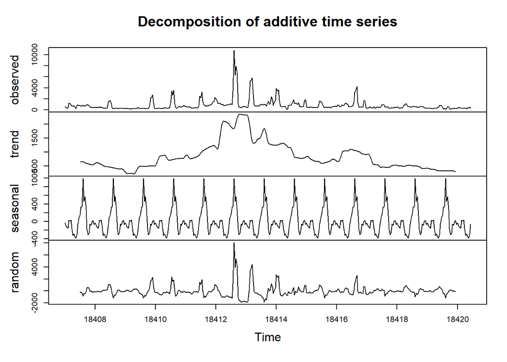

```r
pr1_ts_m=ts(product1$sold_count, frequency=30,start = min(product1$event_date))
pr1_ts_decompose_ma=decompose(pr1_ts_m)
pr1_ts_decompose_mm=decompose(pr1_ts_m, type="multiplicative")
plot(pr1_ts_decompose_ma)
```

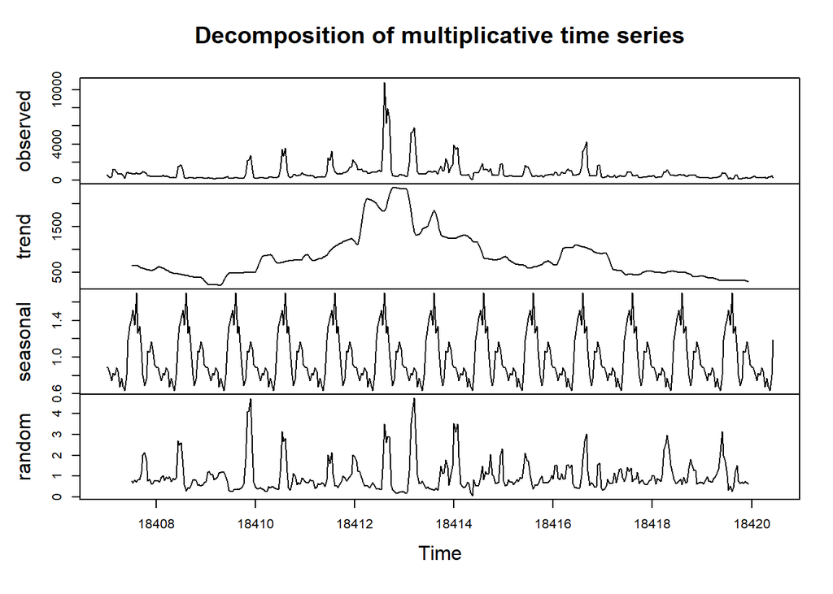

```r
plot(pr1_ts_decompose_mm)
```

### ARIMA

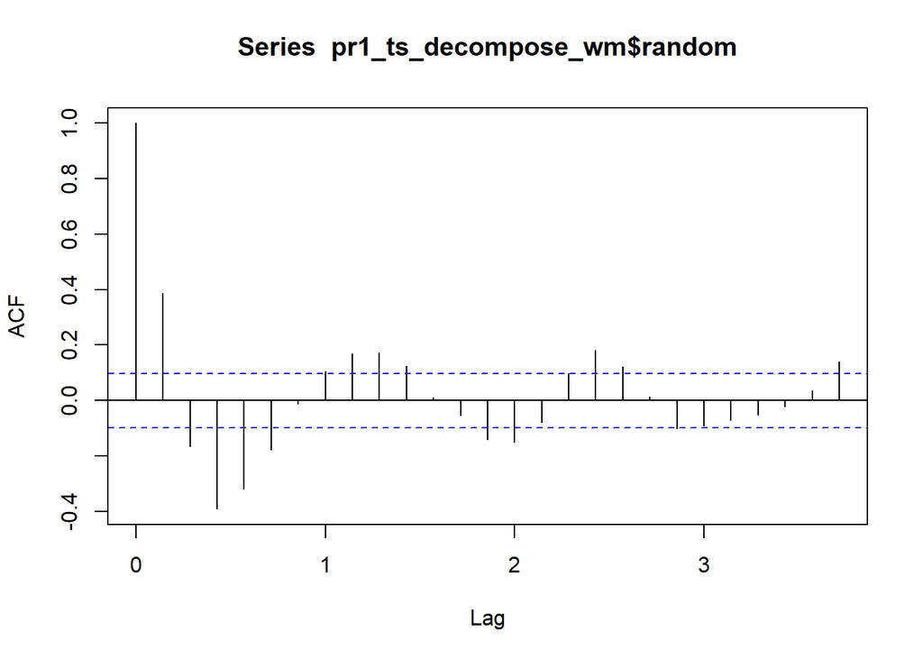

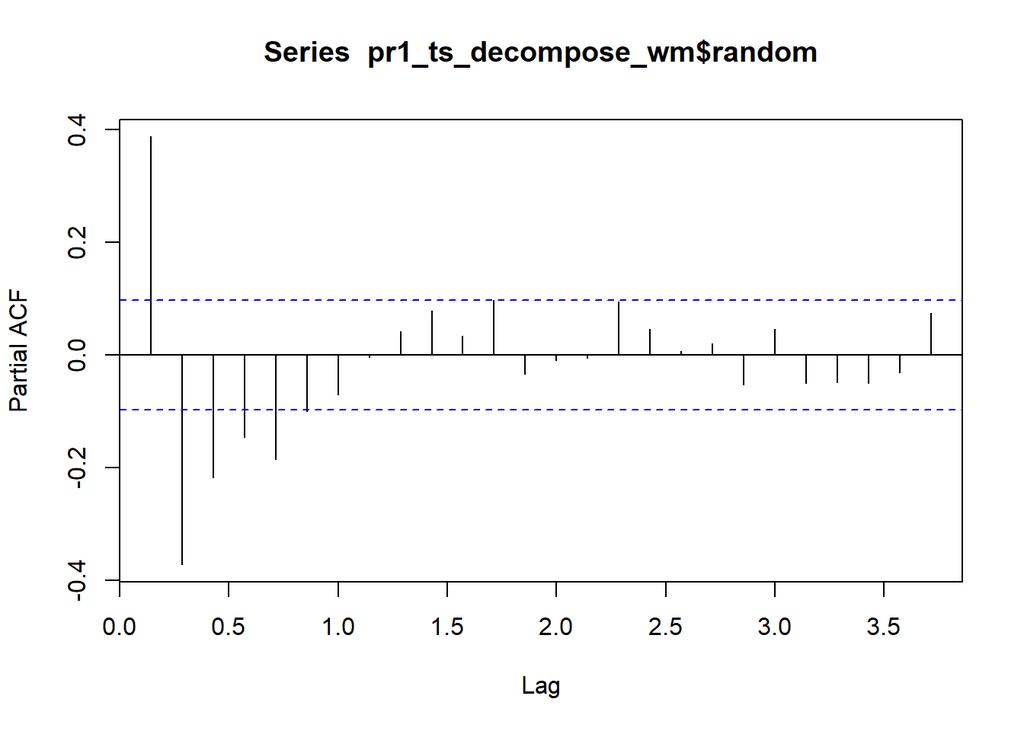

I use auto.arima function to deseasonalized and detrended parts of the products to determine the best models.

```r
pr1_auto=auto.arima(pr1_ts_decompose_wm$random)
pr1_auto
```

```
## Series: pr1_ts_decompose_wm$random
## ARIMA(2,0,1) with non-zero mean
##
## Coefficients:
##          ar1      ar2      ma1    mean
##       1.0717  -0.6016  -0.6832  0.9657
## s.e.  0.0515   0.0409   0.0501  0.0082
##
## sigma^2 estimated as 0.07535:  log likelihood=-48.64
## AIC=107.28   AICc=107.44   BIC=127.22
```

```r
residuals(pr1_auto)
```

[output not shown]

[output cut: 70 more lines]

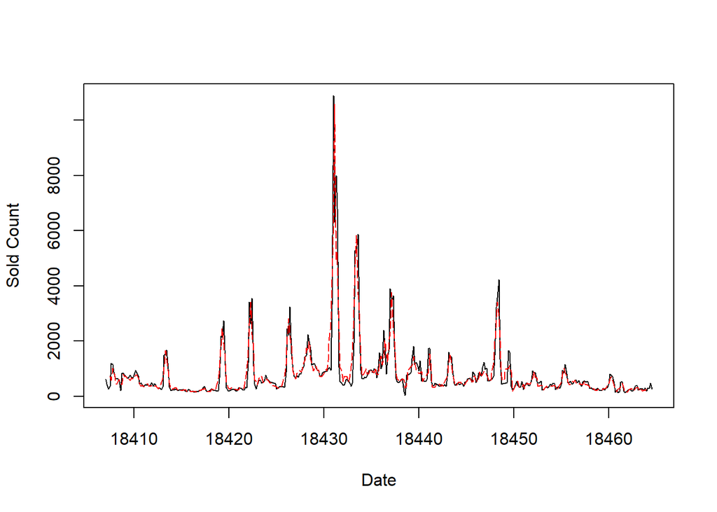

```r
pr1_fitted = pr1_ts_decompose_wm$random - residuals(pr1_auto)
pr1_fitted_transformed = pr1_fitted*pr1_ts_decompose_wm$seasonal*pr1_ts_decompose_wm$trend
plot(pr1_ts_w, xlab="Date", ylab="Sold Count")
points(pr1_fitted_transformed,type="l", col=2, lty=5)
```

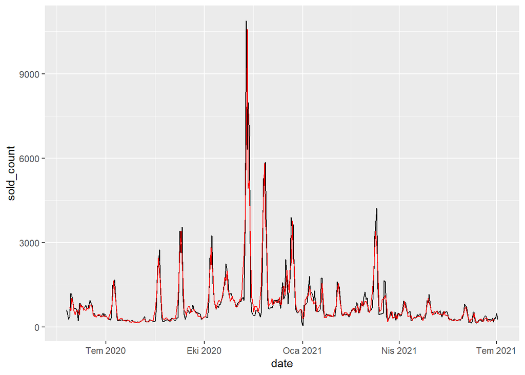

```r
pr1_predictions=cbind(sold_count=pr1_ts_w,fitted=pr1_fitted_transformed)
pr1_predictions=as.data.table(pr1_predictions)
pr1_predictions$date=product1$event_date
ggplot(pr1_predictions, aes(x=date, y=sold_count))+geom_line()+geom_line(aes(y=fitted),col="red")
```

## Product 2

### Data Adjustments

I added new data, sorted observations from old to new and remove repeated elements.

```r
product2= my_data[my_data$product_content_id==32737302,]
product2=(product2[order(product2$event_date),])
prd2_add=data[data$product_content_id==32737302,]
prd2_add=prd2_add[event_date>="2021-06-01",]
prd2_add
```

```
##     price event_date product_content_id sold_count visit_count favored_count
##  1: 61.08 2021-06-01           32737302         73        4981           533
##  2: 61.32 2021-06-02           32737302         61        3693           362
##  3: 60.57 2021-06-03           32737302         70        3530           316
##  4: 61.10 2021-06-04           32737302         50        2792           277
##  5: 59.99 2021-06-05           32737302         32        2824           258
##  6: 59.99 2021-06-06           32737302         50        4239           377
##  7: 62.75 2021-06-07           32737302         44        3237           282
##  8: 63.58 2021-06-08           32737302         46        3266           290
##  9: 61.33 2021-06-09           32737302         41        3059           224
## 10: 61.09 2021-06-10           32737302         49        3080           282
## 11: 59.99 2021-06-11           32737302         37        2750           233
## 12: 66.29 2021-06-12           32737302         41        3081           285
## 13: 62.11 2021-06-13           32737302         73        4842           426
## 14: 61.15 2021-06-14           32737302         88        5109           380
```

[output cut: 87 more lines]

```r
product2=rbind(product2,prd2_add)
product2=unique(product2)
```

### Visualizing

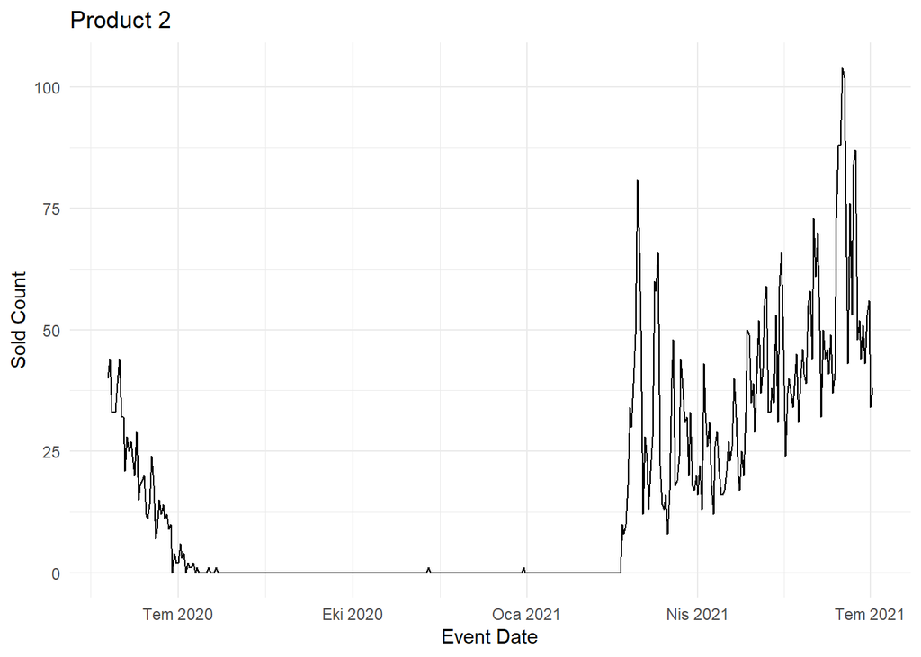

```r
(ggplot(product2,aes(x=event_date,y=sold_count))+
    geom_line()+
    theme_minimal()+
    labs(title="Product 2",y="Sold Count", x="Event Date"))
```

### Analyze Seasonality

In addition to visual analysis, I also used the acf function to test seasonality. Autocorrelation values above the critical value were observed in almost all lag values.

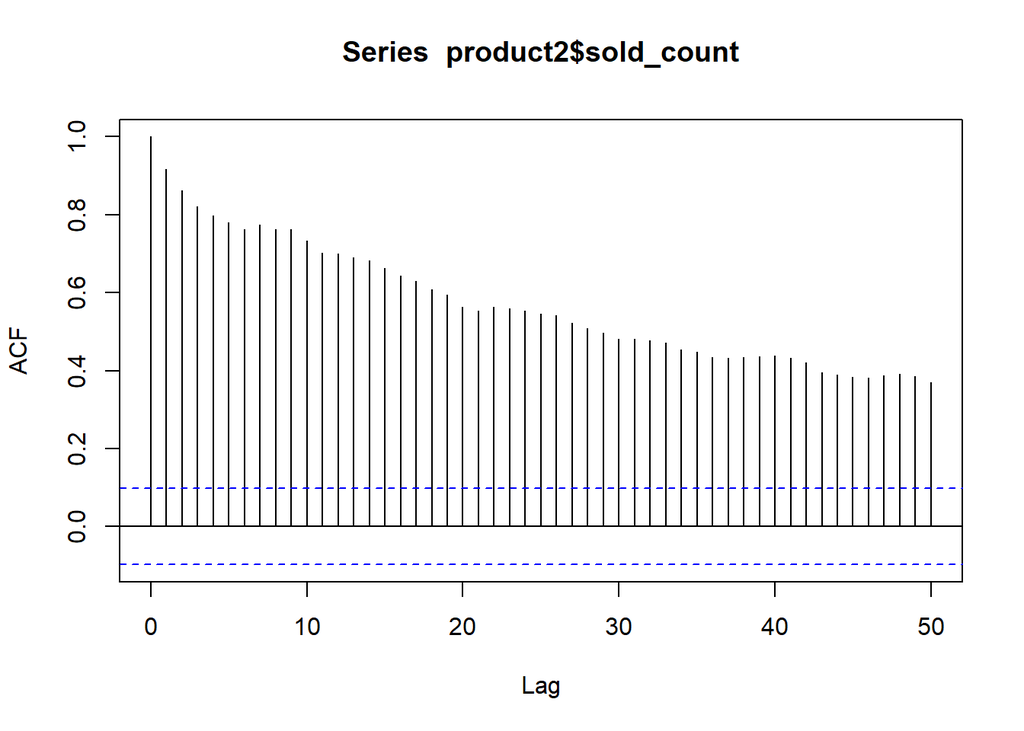

```r
acf(product2$sold_count,50)
```

### Decomposition

I made multiplicative and additive decomposition in weekly and monthly level.

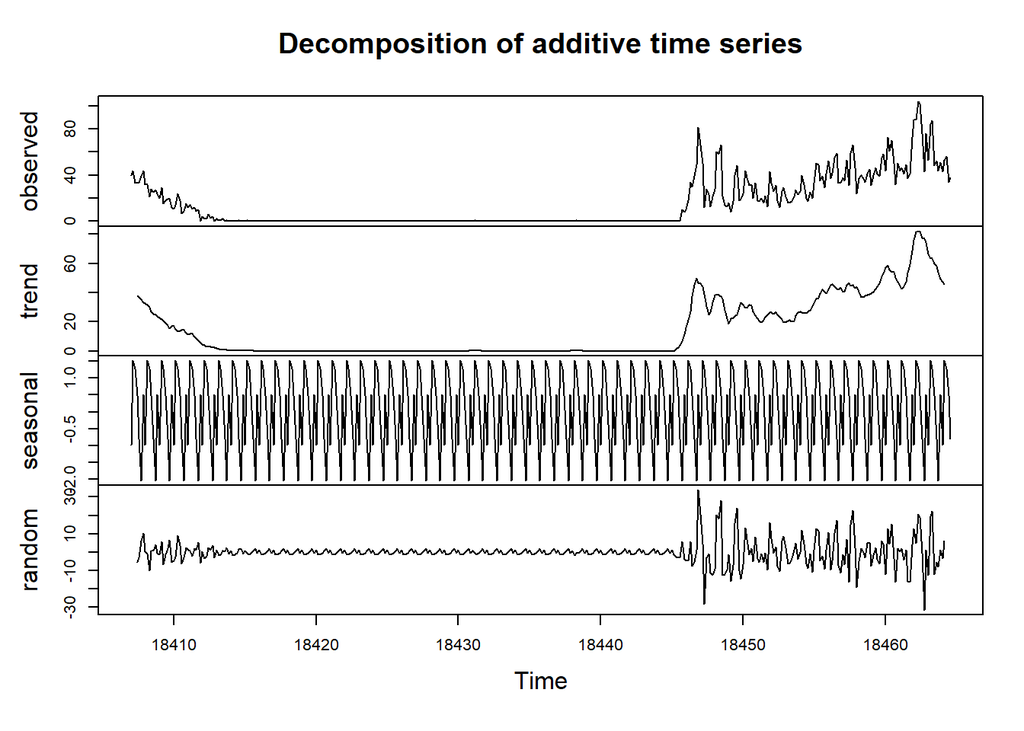

```r
pr2_ts_w=ts(product2$sold_count, frequency=7,start = min(product2$event_date))
pr2_ts_decompose_wa=decompose(pr2_ts_w)
pr2_ts_decompose_wm=decompose(pr2_ts_w, type="multiplicative")
plot(pr2_ts_decompose_wa)
```

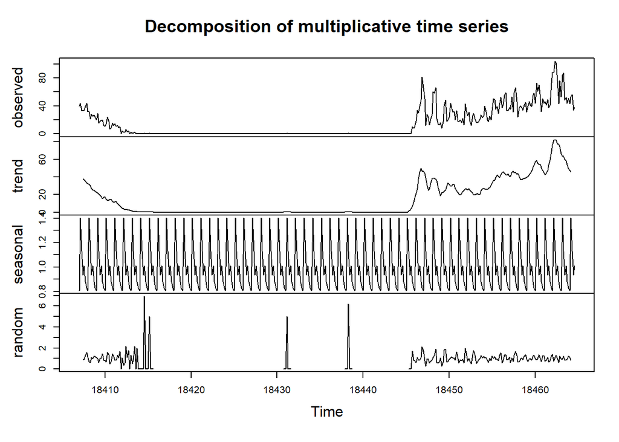

```r
plot(pr2_ts_decompose_wm)
```

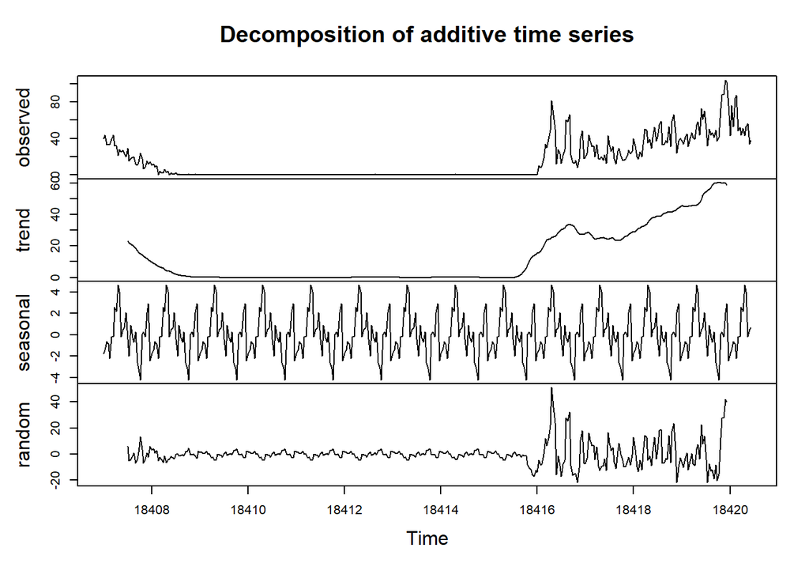

```r
pr2_ts_m=ts(product2$sold_count, frequency=30,start = min(product2$event_date))
pr2_ts_decompose_ma=decompose(pr2_ts_m)
pr2_ts_decompose_mm=decompose(pr2_ts_m, type="multiplicative")
plot(pr2_ts_decompose_ma)
```

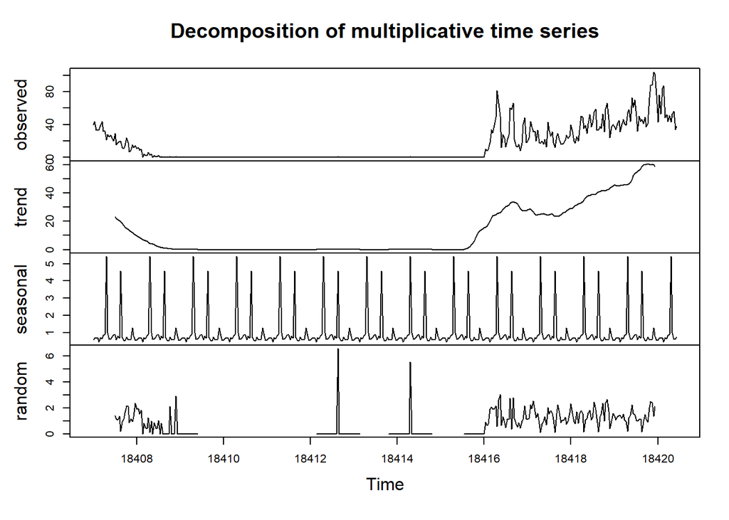

```r
plot(pr2_ts_decompose_mm)
```

### ARIMA

```r
pr2_auto=auto.arima(pr2_ts_decompose_wa$random)
pr2_auto
```

```
## Series: pr2_ts_decompose_wa$random
## ARIMA(5,0,4)(0,0,1)[7] with zero mean
##
## Coefficients:
##         ar1     ar2     ar3      ar4     ar5      ma1      ma2      ma3     ma4
##       0.269  0.4849  0.0540  -0.4852  0.2900  -0.3965  -0.9790  -0.5035  0.8840
## s.e.  0.116  0.0742  0.0578   0.0519  0.0857   0.0977   0.0553   0.0537  0.0964
##          sma1
##       -0.0358
## s.e.   0.0624
##
## sigma^2 estimated as 23.92:  log likelihood=-1195.3
## AIC=2412.6   AICc=2413.28   BIC=2456.45
```

```r
residuals(pr2_auto)
```

[output not shown]

[output cut: 70 more lines]

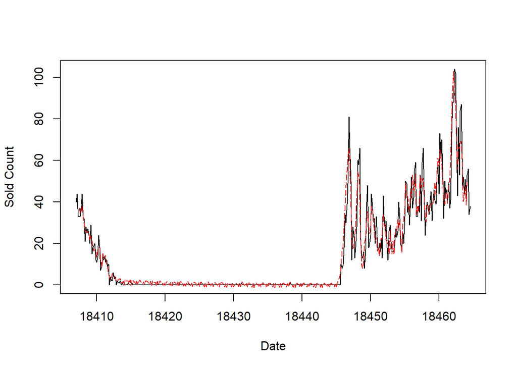

```r
pr2_fitted = pr2_ts_decompose_wa$random - residuals(pr2_auto)
pr2_fitted_transformed = pr2_fitted+pr2_ts_decompose_wa$seasonal+pr2_ts_decompose_wa$trend
plot(pr2_ts_w, xlab="Date", ylab="Sold Count")
points(pr2_fitted_transformed,type="l", col=2, lty=5)
```

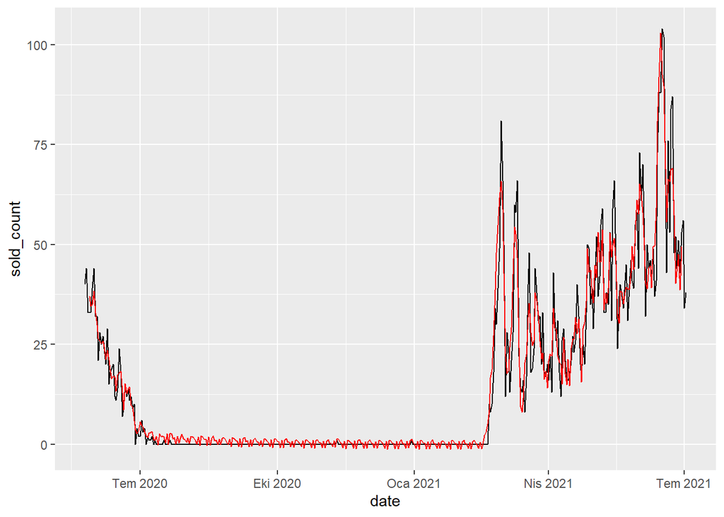

```r
pr2_predictions=cbind(sold_count=pr2_ts_w,fitted=pr2_fitted_transformed)
pr2_predictions=as.data.table(pr2_predictions)
pr2_predictions=cbind(pr2_predictions,date=product2$event_date)
ggplot(pr2_predictions, aes(x=date, y=sold_count))+geom_line()+geom_line(aes(y=fitted),col="red")
```

## Product 3

### Data Adjustments

I added new data and sorted observations from old to new.

```r
product3= my_data[my_data$product_content_id==32939029,]
product3=(product3[order(product3$event_date),])
prd3_add=data[data$product_content_id==32939029,]
prd3_add=prd3_add[event_date>="2021-06-01",]
prd3_add
```

```
##      price event_date product_content_id sold_count visit_count favored_count
##  1: 147.55 2021-06-01           32939029        141        5775           623
##  2: 138.39 2021-06-02           32939029        315        9748          1858
##  3: 138.94 2021-06-03           32939029        264        6507           785
##  4: 137.90 2021-06-04           32939029        217        5521           557
##  5: 149.75 2021-06-05           32939029         90        4484           522
##  6: 156.23 2021-06-06           32939029        127        5233           712
##  7: 158.13 2021-06-07           32939029        116        4535           502
##  8: 155.56 2021-06-08           32939029        133        4551           447
##  9: 156.06 2021-06-09           32939029         84        4179           422
## 10: 157.71 2021-06-10           32939029        100        3649           355
## 11: 151.23 2021-06-11           32939029         76        3039           477
## 12: 154.59 2021-06-12           32939029         83        3012           433
## 13: 155.68 2021-06-13           32939029        115        3994           573
## 14: 140.86 2021-06-14           32939029        245        5633           755
```

[output cut: 87 more lines]

```r
product3=rbind(product3,prd3_add)
```

### Visualizing

The plot of the series is shown below.It is observed that there is a mean shift starting from the spring of 2021. Variance of the series is not constant.

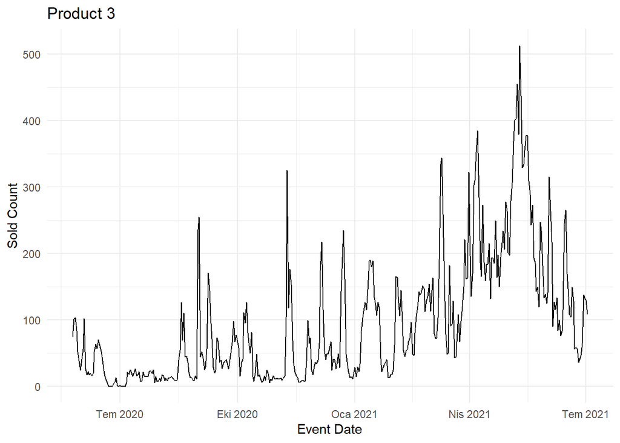

```r
(ggplot(product3,aes(x=event_date,y=sold_count))+
    geom_line()+
    theme_minimal()+
    labs(title="Product 3",y="Sold Count", x="Event Date"))
```

### Analyze Seasonality

In addition to visual analysis, I also used the acf function to test seasonality. Autocorrelation values above the critical value were observed in almost all lag values.

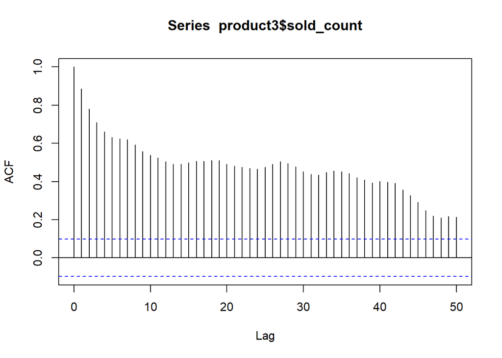

```r
acf(product3$sold_count,50)
```

### Decomposition

I made multiplicative and additive decomposition in weekly and monthly level.

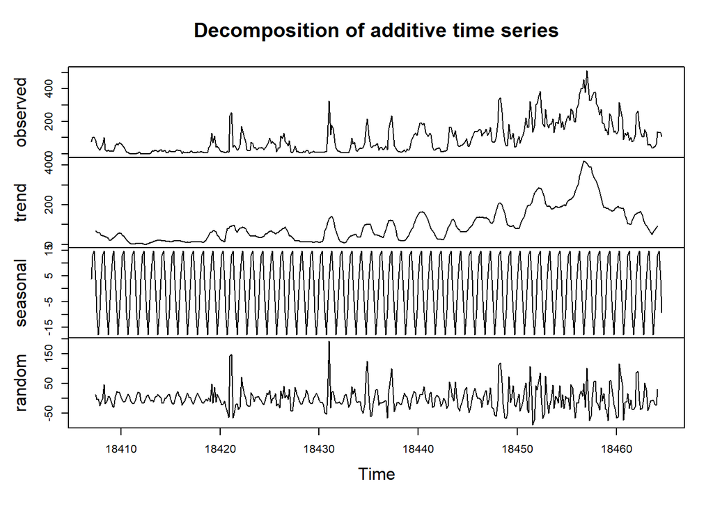

```r
pr3_ts_w=ts(product3$sold_count, frequency=7,start = min(product3$event_date))
pr3_ts_decompose_wa=decompose(pr3_ts_w)
pr3_ts_decompose_wm=decompose(pr3_ts_w, type="multiplicative")
plot(pr3_ts_decompose_wa)
```

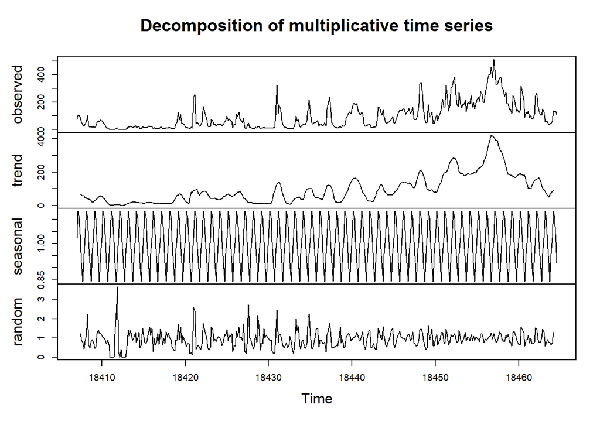

```r
plot(pr3_ts_decompose_wm)
```

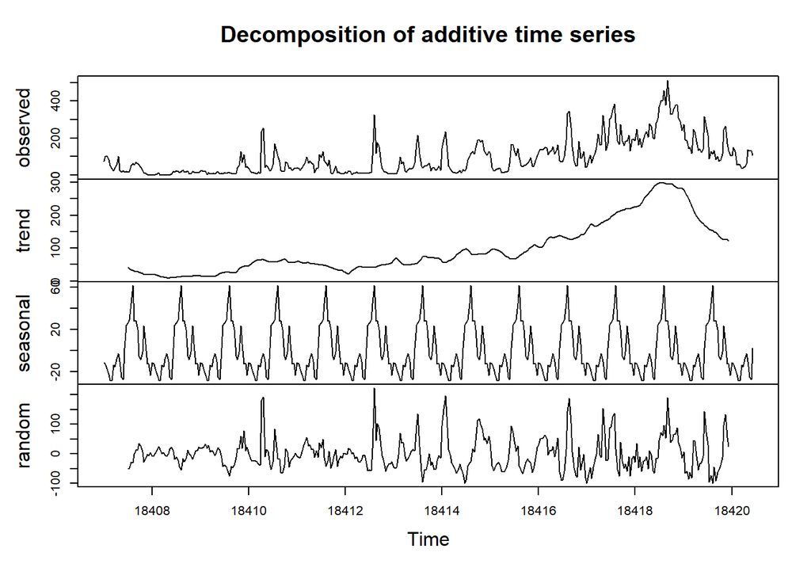

```r
pr3_ts_m=ts(product3$sold_count, frequency=30,start = min(product3$event_date))
pr3_ts_decompose_ma=decompose(pr3_ts_m)
pr3_ts_decompose_mm=decompose(pr3_ts_m, type="multiplicative")
plot(pr3_ts_decompose_ma)
```

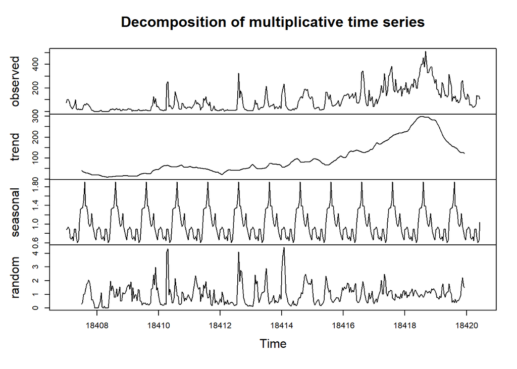

```r
plot(pr3_ts_decompose_mm)
```

### ARIMA

```r
pr3_auto=auto.arima(pr3_ts_decompose_wm$random)
pr3_auto
```

```
## Series: pr3_ts_decompose_wm$random
## ARIMA(2,0,1)(1,0,0)[7] with non-zero mean
##
## Coefficients:
##          ar1      ar2      ma1     sar1    mean
##       1.0229  -0.4712  -0.6957  -0.0721  0.9463
## s.e.  0.0656   0.0443   0.0633   0.0539  0.0124
##
## sigma^2 estimated as 0.1519:  log likelihood=-187.51
## AIC=387.03   AICc=387.24   BIC=410.95
```

```r
residuals(pr3_auto)
```

[output not shown]

[output cut: 70 more lines]

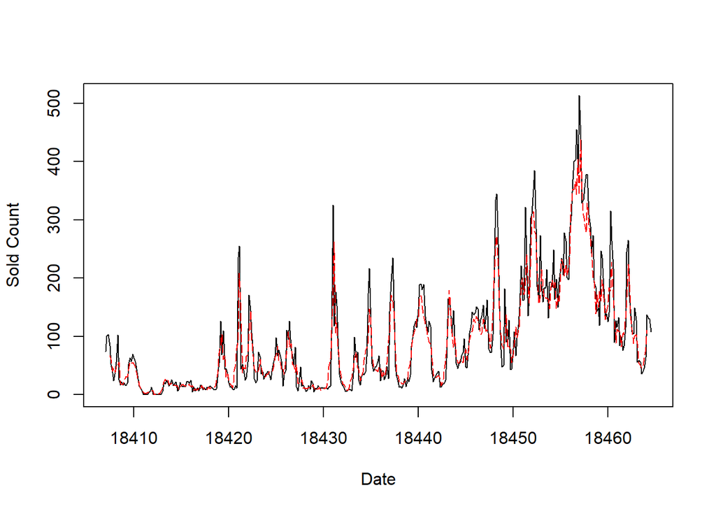

```r
pr3_fitted = pr3_ts_decompose_wm$random - residuals(pr3_auto)
pr3_fitted_transformed = pr3_fitted*pr3_ts_decompose_wm$seasonal*pr3_ts_decompose_wm$trend
plot(pr3_ts_w, xlab="Date", ylab="Sold Count")
points(pr3_fitted_transformed,type="l", col=2, lty=5)
```

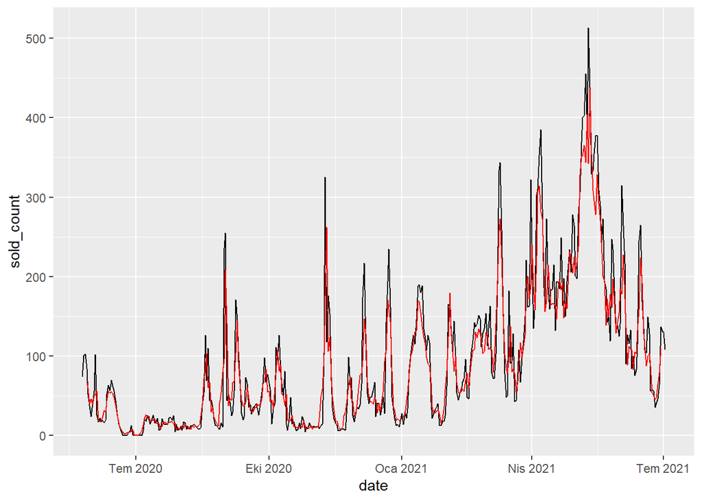

```r
pr3_predictions=cbind(sold_count=pr3_ts_w,fitted=pr3_fitted_transformed)
pr3_predictions=as.data.table(pr3_predictions)
pr3_predictions$date=product3$event_date
ggplot(pr3_predictions, aes(x=date, y=sold_count))+geom_line()+geom_line(aes(y=fitted),col="red")
```

## Product 4

### Data Adjustments

I added new data and sorted observations from old to new.

```r
product4= my_data[my_data$product_content_id==4066298,]
product4=(product4[order(product4$event_date),])
prd4_add=data[data$product_content_id==4066298,]
prd4_add=prd4_add[event_date>="2021-06-01",]
prd4_add
```

```
##     price event_date product_content_id sold_count visit_count favored_count
##  1: 65.05 2021-06-01            4066298        969       14839          1998
##  2: 64.99 2021-06-02            4066298        767        9574          1058
##  3: 65.02 2021-06-03            4066298        725        8082           724
##  4: 64.99 2021-06-04            4066298        533        6132           469
##  5: 64.99 2021-06-05            4066298        386        4644           241
##  6: 65.38 2021-06-06            4066298        448        5092           297
##  7: 70.43 2021-06-07            4066298        266        4200           230
##  8: 72.56 2021-06-08            4066298        249        3821           203
##  9: 72.66 2021-06-09            4066298        244        3670           209
## 10: 72.50 2021-06-10            4066298        253        3492           181
## 11: 72.56 2021-06-11            4066298        230        3067           175
## 12: 72.60 2021-06-12            4066298        236        3245           177
## 13: 72.54 2021-06-13            4066298        298        3806           226
## 14: 72.67 2021-06-14            4066298        269        3867           226
```

[output cut: 87 more lines]

```r
product4=rbind(product4,prd4_add)
```

### Visualizing

The plot of the series is shown below.Seasonality is observed in 2020, however there is not any seasonality in 2021.Variance of the series is not constant. There are several short periods with high sales.

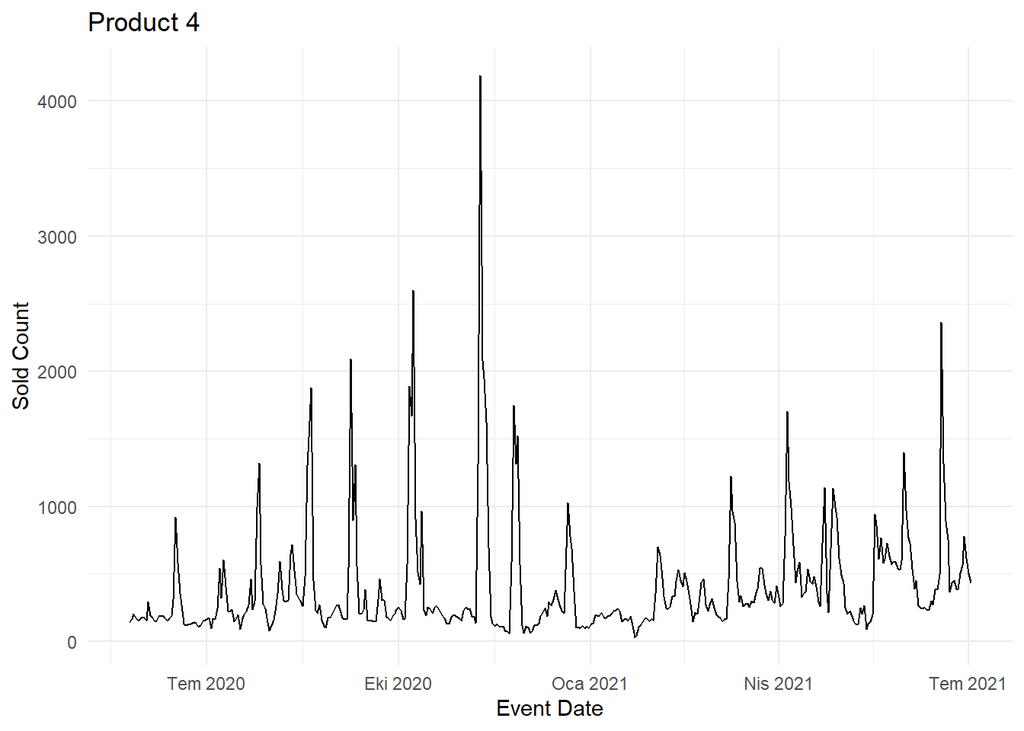

```r
(ggplot(product4,aes(x=event_date,y=sold_count))+
    geom_line()+
    theme_minimal()+
    labs(title="Product 4",y="Sold Count", x="Event Date"))
```

### Analyze Seasonality

In addition to visual analysis, I also used the acf function to test seasonality.

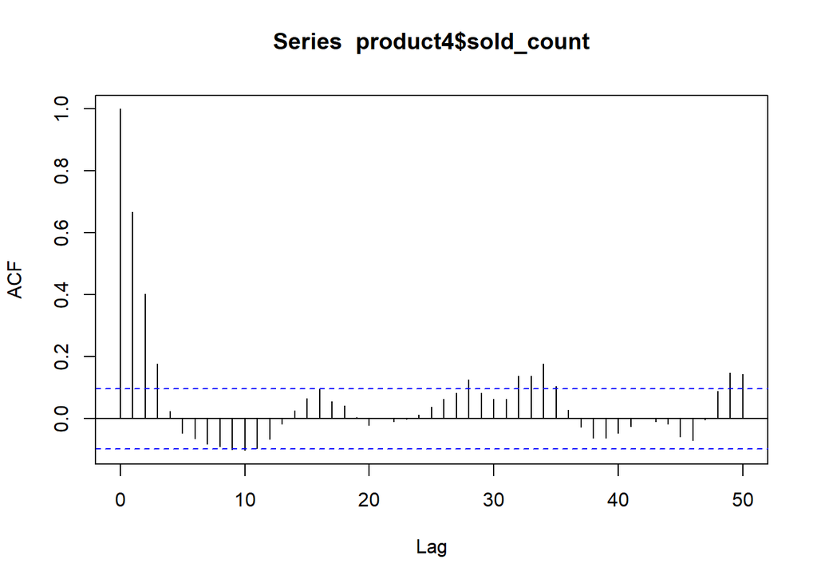

```r
acf(product4$sold_count,50)
```

### Decomposition

I made multiplicative and additive decomposition in weekly and monthly level.

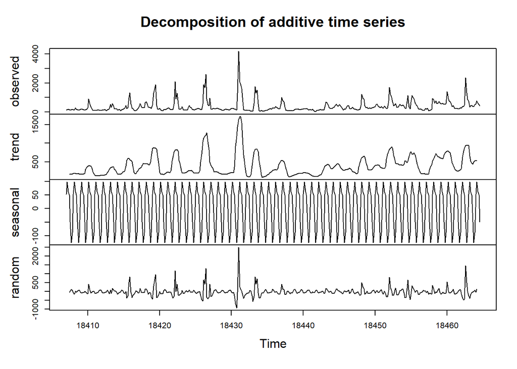

```r
pr4_ts_w=ts(product4$sold_count, frequency=7,start = min(product4$event_date))
pr4_ts_decompose_wa=decompose(pr4_ts_w)
pr4_ts_decompose_wm=decompose(pr4_ts_w, type="multiplicative")
plot(pr4_ts_decompose_wa)
```

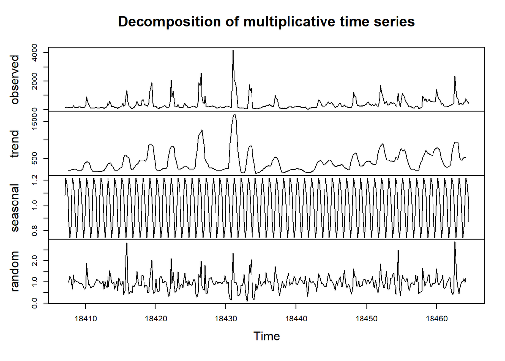

```r
plot(pr4_ts_decompose_wm)
```

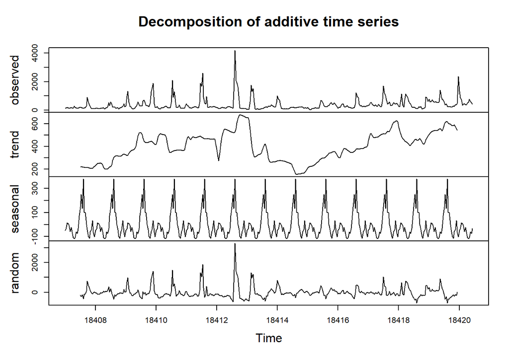

```r
pr4_ts_m=ts(product4$sold_count, frequency=30,start = min(product4$event_date))
pr4_ts_decompose_ma=decompose(pr4_ts_m)
pr4_ts_decompose_mm=decompose(pr4_ts_m, type="multiplicative")
plot(pr4_ts_decompose_ma)
```

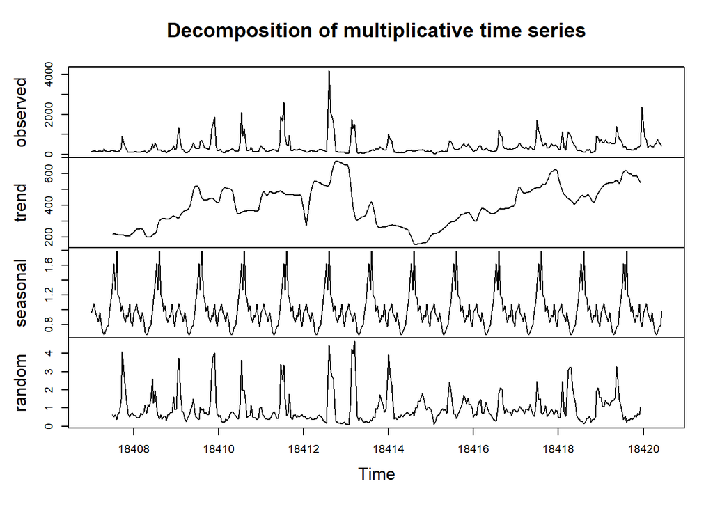

```r
plot(pr4_ts_decompose_mm)
```